# Отчёт по выполнению домашней работы №3

Работа с вайршарк

Коровкин Н. М.

Российский университет дружбы народов, Москва, Россия

16 феврался 2026

# Информация

## Докладчик

- Коровкин Никита Михайлович
- Студент
- Российский университет дружбы народов
- 1132246835@pfur.ru

## Цель работы

Изучение посредством Wireshark кадров Ethernet, анализ PDU протоколов транспортного и прикладного уровней стека TCP/IP.

## Задание

1. Изучение возможностей команды ipconfig для ОС типа Windows (ifconfig для систем типа Linux).
2. Определение MAC-адреса устройства и его типа
3. Установить на домашнем устройстве Wireshark.
4. С помощью Wireshark захватить и проанализировать пакеты ARP и ICMP в части кадров канального уровня.
5. С помощью Wireshark захватить и проанализировать пакеты HTTP, DNS в части заголовков и информации протоколов TCP, UDP, QUIC.
6. С помощью Wireshark проанализировать handshake протокола TCP

## Выполнение лабораторной работы

Для получения информации о сетевых интерфейсах на компьютере была использована команда ifconfig. Поле ether содержит MAC-адрес сетевого интерфейса. Поле inet содержит IPv4-адрес устройства. Поле netmask определяет маску подсети, а broadcast содержит широковещательный адрес сети. Далее я узнал непосредственно Айпи адрес и адрес шлюза.

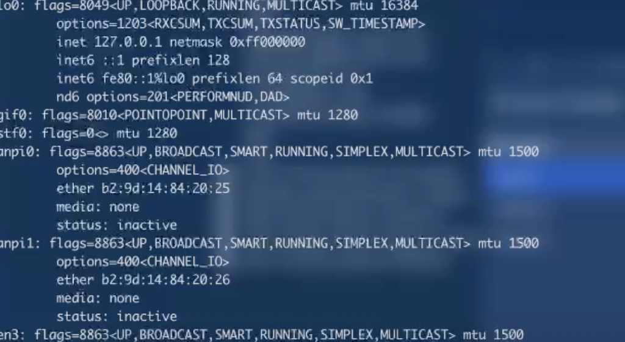

## Определение мак адреса

[figure not shown]

## Изучение полученного мак-адреса

Последние три байта используются для идентификации конкретного сетевого интерфейса в соответствующем диапазоне адресов

## Отслеживание трафика

Для анализа сетевого трафика была запущена программа Wireshark.[@wireshark_doc]

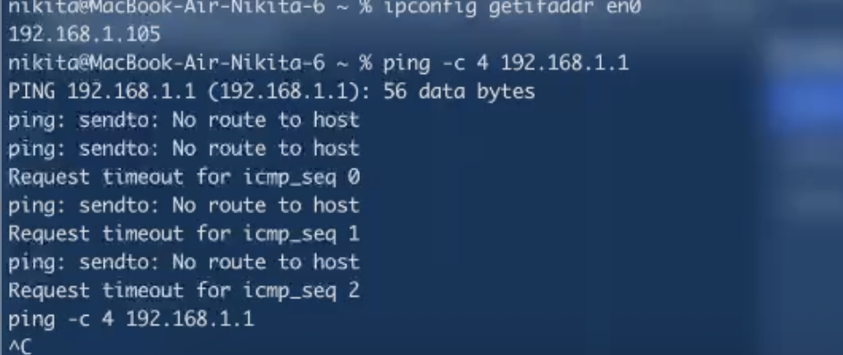

## Пинг

После запуска захвата в Wireshark начали отображаться передаваемые сетевые пакет.

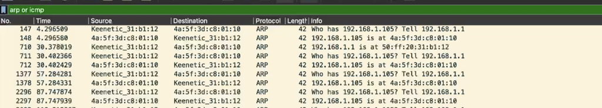

ping

## Выполнение лабораторной работы

В результате были получены ответы от шлюза, что подтверждает его доступность.

После завершения захвата в Wireshark был применён фильтр: arp or icmp Фильтр оставляет в списке только пакеты протоколов ARP и ICMP.В результате были получены ответы от шлюза, что подтверждает его доступность.

[figure not shown]

arp or icmp

## Исследование полученного пакета

В захваченном трафике был выбран пакет ICMP Echo Request, сформированный в результате выполнения команды ping.

В структуре пакета был исследован заголовок Ethernet II

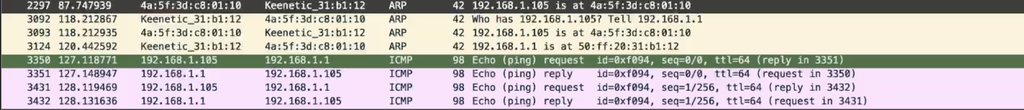

исследование пакета

## Исследование пакета

MAC-адрес источника соответствует сетевому интерфейсу компьютера, поскольку именно компьютер сформировал ICMP-запрос.

MAC-адрес назначения соответствует сетевому интерфейсу шлюза, поскольку пакет передаётся маршрутизатору. В поле Type заголовка Ethernet II указывается протокол сетевого уровня, переносимый данным Ethernet-кадром. Для IPv4 используется значение 0x0800.

[figure not shown]

исследование пакета

## Выполнение лабораторной работы

В данном случае MAC-адреса источника и назначения поменялись местами по сравнению с Echo Request.

Это объясняется направлением передачи данных: ответ отправляется от шлюза обратно к компьютеру.

## Анализ ARP

ARP (Address Resolution Protocol) используется для определения MAC-адреса устройства по известному IPv4-адресу в пределах локальной сети. При необходимости передачи пакета шлюзу компьютер должен знать не только его IP-адрес, но и MAC-адрес. Для этого используется ARP Request. В Ethernet II заголовке ARP-запроса в качестве MAC-адреса назначения обычно используется: ff:ff:ff:ff:ff:ff Это широковещательный MAC-адрес.

Он означает, что Ethernet-кадр должен быть доставлен всем устройствам соответствующего локального сегмента.

## Выполнение лабораторной работы

Для ARP Request поле Opcode имеет значение request. Для ARP Reply оно имеет значение reply.

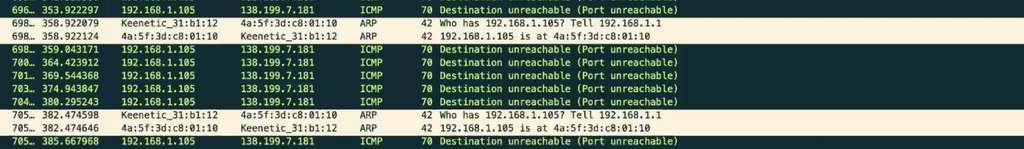

Arp

## Выполнение лабораторной работы

Для дополнительного исследования был начат новый захват трафика.

В командной строке была выполнена команда: ping -c 4 rudn.ru После этого захват был остановлен и применён фильтр: arp or icmp При обращении к удалённому узлу сначала необходимо определить его IP-адрес по доменному имени. После определения IP-адреса ICMP-пакеты передаются через шлюз по умолчанию.

[figure not shown]

## Выполнение лабораторной работы

Для анализа HTTP был начат новый захват трафика.

В браузере был открыт ресурс:

http://info.cern.ch/ Данный ресурс использует протокол HTTP.

После открытия страницы в Wireshark был применён фильтр: http В результате были обнаружены HTTP-пакеты. HTTP работает поверх TCP. Поэтому при анализе HTTP-пакета также можно исследовать TCP-заголовок.

## CERN - пинг

В TCP-заголовке были рассмотрены:

- порт источника;
- порт назначения;
- Sequence Number;
- Acknowledgment Number;
- TCP Flags;
- Window Size;
- TCP Options.

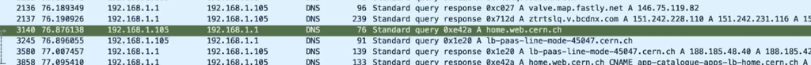

## DNS

Для анализа DNS был использован фильтр dns.DNS используется для преобразования доменных имён в IP-адреса.

Например, перед установлением соединения с сервером по доменному имени клиенту необходимо определить IP-адрес соответствующего сервера. В DNS-запросе указывается имя узла, для которого необходимо получить сетевой адрес. DNS обычно использует UDP, поэтому в захваченном пакете присутствует заголовок UDP.

[figure not shown]

## QUIC

Для исследования протокола QUIC был выполнен захват соответствующего сетевого трафика. QUIC является транспортным протоколом, работающим поверх UDP.

Упрощённая структура передачи имеет вид

HTTP/3 ↓ QUIC ↓ UDP ↓ IP ↓ Ethernet/Wi-Fi В отличие от классической схемы HTTP поверх TCP, QUIC использует UDP в качестве основы транспортной передачи.

При анализе пакета были исследованы сведения о QUIC-соединении и содержащиеся в нём поля.

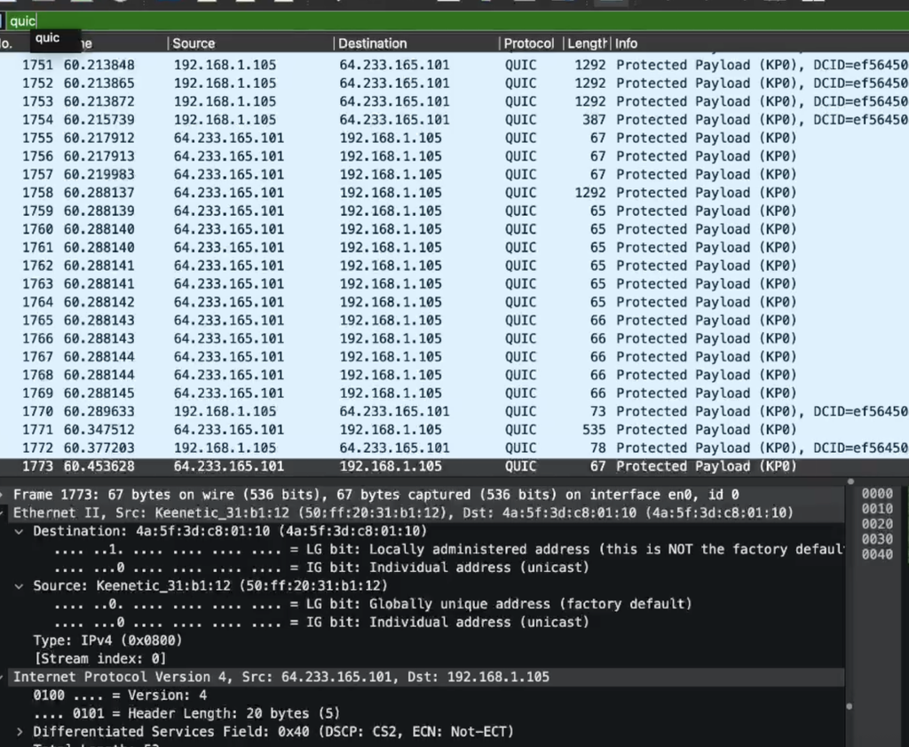

quic

## проверка тсп

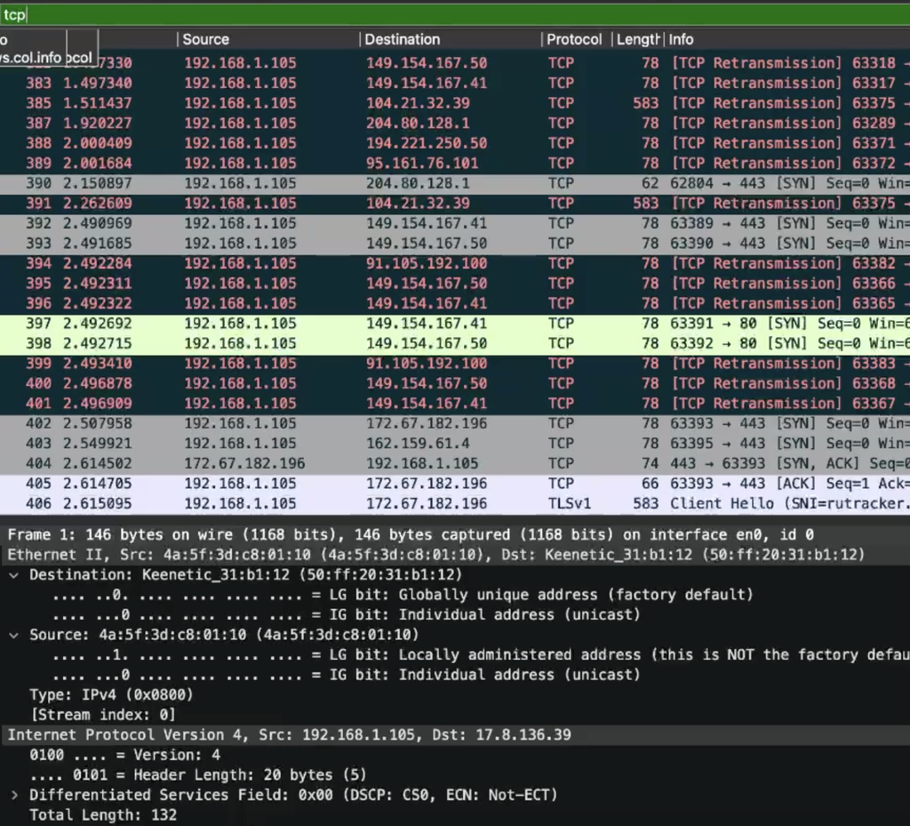

tcp

## Построение графика

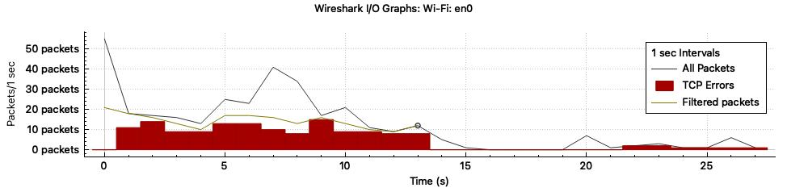

график

## Выводы

В ходе лабораторной работы были изучены основные средства получения информации о сетевых параметрах компьютера с помощью командной строки.